# Proportions Test (MSM vs IDU)

October 21, 2015

### **Mortality Analysis for the period 2003 to 2014**

#### *HIV Mortality Analysis*

In order to explore HIV Mortality in Puerto Rico, we conducted a crude analysis using the data from the HIV Surveillance System for 2003 to 2014. The trend in HIV mortality can be seeing in figure 1:

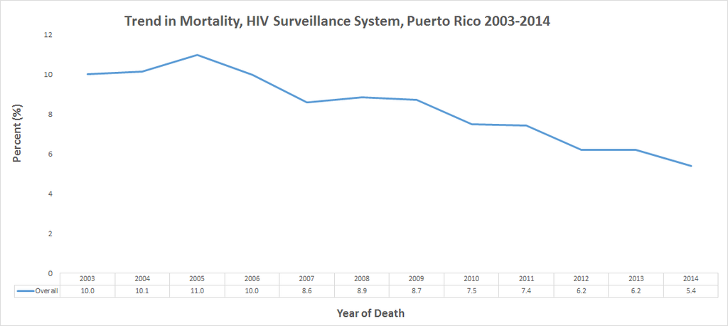

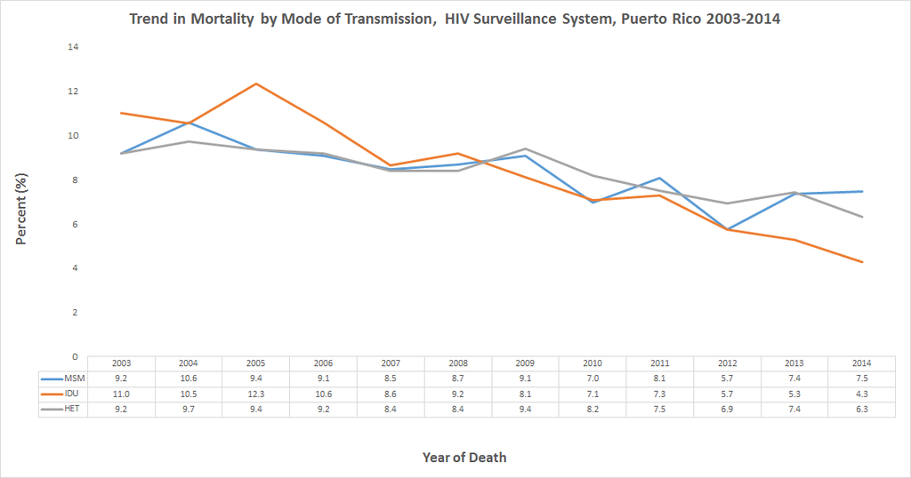

Figure 2 also shows a decreasing trend in HIV in Puerto Rico. In the IDU group, we can see a decrease of almost 7% which might explain the reason why the overall mortality is also decreasing.

#### *Comparing deaths of Men who have Sex with Men (MSM) and Injected Drugs Users (IDU)*

In order to compare deaths among MSM and IDU, we calculate the absolute difference between years (according to the CDC mathematical model) and verify whether there was a significant difference between these groups. The raw file can be accessed [here.](https://github.com/kramus/proptest/blob/master/propt3.csv)  
The structure of the data is as follows:

```
##           year 2004 2005 2006 2007 2008 2009 2010 2011 2012 2013 2014
## type case
## msm  yes         14   12    3    6    2    4   21   11   23   16    1
##      no          91  105   93   90   84   86   90   69   80   57   73
## idu  yes         17   66   64   72   20   39   38    7   57   17   36
##      no         405  388  454  390  318  338  299  261  268  211  194
```

The absolute differences of MSM and IDU cases for 2004-2014 are:

```
##
## ------------------
##  year   MSM   IDU
## ------ ----- -----
##  2004  0.154 0.042
##
##  2005  0.114 0.17
##
##  2006  0.032 0.141
##
##  2007  0.067 0.185
##
##  2008  0.024 0.063
##
##  2009  0.047 0.115
##
##  2010  0.233 0.127
##
##  2011  0.159 0.027
##
##  2012  0.288 0.213
##
##  2013  0.281 0.081
##
##  2014  0.014 0.186
## ------------------
```

To perform the analysis we used a function to divide the dataset by year to calculate whether there was a difference between cases of HIV for MSM and IDU by specific years. The p-values were:

| Year | p_value |
| --- | --- |
| 2004 | 0.0007 |
| 2005 | 0.2931 |
| 2006 | 0.0129 |
| 2007 | 0.0252 |
| 2008 | 0.2750 |
| 2009 | 0.1244 |
| 2010 | 0.0570 |
| 2011 | 0.0004 |
| 2012 | 0.3462 |
| 2013 | 0.0013 |
| 2014 | 0.0022 |

We can see that for years 2005, 2008, 2009, 2010 and 2012 the results were not statistically significant (0.2931, 0.275, 0.1244, 0.057, 0.3462 respectively). Further investigation will be needed in order to have a better insight of the behavior of HIV mortality in Puerto Rico.